# Project Part 1

#### Importing Modules

```python
import os
import numpy as np
import pandas as pd
import cv2
import matplotlib.pyplot as plt
%matplotlib inline

import warnings
warnings.filterwarnings('ignore')

from sklearn.model_selection import train_test_split
import itertools

from keras.preprocessing import image
from keras.preprocessing.image import ImageDataGenerator
from keras.callbacks import ReduceLROnPlateau
from keras.models import Sequential, Model
from keras.layers import Dense, Activation, Flatten, Dropout, concatenate, Input, Conv2D, MaxPooling2D
from keras.optimizers import Adam, Adadelta
from keras.layers.advanced_activations import LeakyReLU
from keras.utils.np_utils import to_categorical
```

```python
from sklearn.metrics import classification_report
```

```python
#!pip install opencv-python
```

#### Viewing data

```python
import os
rootdir='F:\\GreatLearning\\AI\\ComputerVision\\Project\\plant_seeding_classification_data\\train\\'

for file in os.listdir(rootdir):
    d = os.path.join(rootdir, file)
    if os.path.isdir(d):
        print(file)
```

```
Black-grass
Charlock
Cleavers
Common Chickweed
Common wheat
Fat Hen
Loose Silky-bent
Maize
Scentless Mayweed
Shepherds Purse
Small-flowered Cranesbill
Sugar beet
```

- We have 12 species of plants avaialable for training

```python
for file in os.listdir(rootdir):
    d = os.path.join(rootdir, file)
    if os.path.isdir(d):
        print(file)
```

```
Black-grass
Charlock
Cleavers
Common Chickweed
Common wheat
Fat Hen
Loose Silky-bent
Maize
Scentless Mayweed
Shepherds Purse
Small-flowered Cranesbill
Sugar beet
```

```python
import glob
os.chdir(d)
count=0
imgList=[]
for file in glob.glob("*.PNG"):
    print(file)
    count+=1
    imgList.append(file)
    if (count==10):
        break
```

```
0026b7a30.png
00626e3be.png
008753052.png
00acffa82.png
019e2ca3b.png
01f145914.png
02460681c.png
04c979351.png
05f87cff9.png
06a859dfd.png
```

- From first glance, images are in png format

```python
imgList
```

```
['0026b7a30.png',
 '00626e3be.png',
 '008753052.png',
 '00acffa82.png',
 '019e2ca3b.png',
 '01f145914.png',
 '02460681c.png',
 '04c979351.png',
 '05f87cff9.png',
 '06a859dfd.png']
```

```python
img1= os.path.join(d, imgList[0])

import imageio
import matplotlib.pyplot as plt
%matplotlib inline

#function created for viewing basic data features of images
def imgBasics(path,imgName):
    img1= os.path.join(path, imgName)
    pic = imageio.imread(img1)
    plt.figure(figsize = (5,5))
    plt.imshow(pic)

    #Basic properties of image
    print('Type of the image : ' , type(pic))
    print('Shape of the image : {}'.format(pic.shape))
    print('Image Hight {}'.format(pic.shape[0]))
    print('Image Width {}'.format(pic.shape[1]))
    print('Dimension of Image {}'.format(pic.ndim))
    print('Image size {}'.format(pic.size))
    print('Maximum RGB value in this image {}'.format(pic.max()))
    print('Minimum RGB value in this image {}'.format(pic.min()))
    print('Value of only R channel {}'.format(pic[ 100, 50, 0]))
    print('Value of only G channel {}'.format(pic[ 100, 50, 1]))
    print('Value of only B channel {}'.format(pic[ 100, 50, 2]))
```

```
Type of the image :  <class 'imageio.core.util.Array'>
Shape of the image : (756, 756, 3)
Image Hight 756
Image Width 756
Dimension of Image 3
Image size 1714608
Maximum RGB value in this image 207
Minimum RGB value in this image 0
Value of only R channel 105
Value of only G channel 79
Value of only B channel 57
```

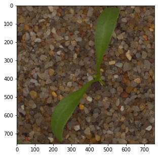

```python
imgBasics(d,imgList[0])
```

```
Type of the image :  <class 'imageio.core.util.Array'>
Shape of the image : (510, 510, 3)
Image Hight 510
Image Width 510
Dimension of Image 3
Image size 780300
Maximum RGB value in this image 173
Minimum RGB value in this image 0
Value of only R channel 94
Value of only G channel 72
Value of only B channel 52
```

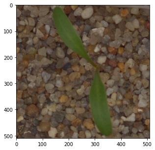

```python
imgBasics(d,imgList[1])
```

```
Type of the image :  <class 'imageio.core.util.Array'>
Shape of the image : (481, 481, 3)
Image Hight 481
Image Width 481
Dimension of Image 3
Image size 694083
Maximum RGB value in this image 167
Minimum RGB value in this image 0
Value of only R channel 99
Value of only G channel 76
Value of only B channel 59
```

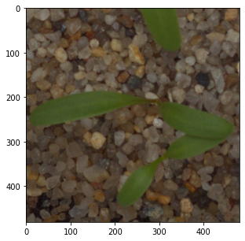

```python
imgBasics(d,imgList[2])
```

```
Type of the image :  <class 'imageio.core.util.Array'>
Shape of the image : (1023, 1023, 3)
Image Hight 1023
Image Width 1023
Dimension of Image 3
Image size 3139587
Maximum RGB value in this image 247
Minimum RGB value in this image 0
Value of only R channel 84
Value of only G channel 104
Value of only B channel 52
```

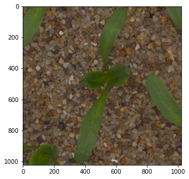

```python
imgBasics(d,imgList[9])
```

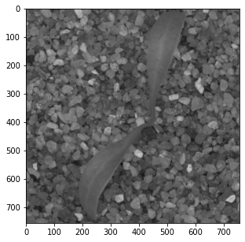

```python
pic = imageio.imread(img1)
gray = lambda rgb : np.dot(rgb[... , :3] , [0.299 , 0.587, 0.114])
gray = gray(pic)
plt.figure( figsize = (5,5))
plt.imshow(gray, cmap = plt.get_cmap(name = 'gray'))
plt.show()
```

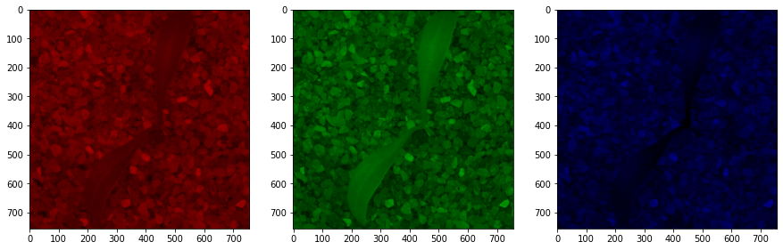

```python
import numpy as np
pic = imageio.imread(img1)
fig, ax = plt.subplots(nrows = 1, ncols=3, figsize=(15,5))
for c, ax in zip(range(3), ax):
     split_img = np.zeros(pic.shape, dtype="uint8")
     split_img[ :, :, c] = pic[ :, :, c]
     ax.imshow(split_img)
```

- Images are of very diferent resolutions, ranging from 1023x1023 to 481x481
- they have 3 channnels (RGB)
- Lot of details avialable apart from just the plant species like sand grains or stone or scales

### Loading Data

#### Exploring the folders containing data

```python
#Understaanding data for loading
train_dir = 'F:/GreatLearning/AI/ComputerVisionProject/plant_seeding_classification_data/train'
test_dir  = 'F:/GreatLearning/AI/ComputerVisionProject/plant_seeding_classification_data/test'
sample_submission = pd.read_csv('F:\GreatLearning\AI\ComputerVision\Project\plant_seeding_classification_data\sample_submission.csv')
```

```python
def get_immediate_subdirectories(a_dir):
    return [name for name in os.listdir(a_dir)
            if os.path.isdir(os.path.join(a_dir, name))]
```

```python
specPath='F:\\GreatLearning\\AI\\ComputerVision\\Project\\plant_seeding_classification_data\\train\\'
specPathTest='F:\\GreatLearning\\AI\\ComputerVision\\Project\\plant_seeding_classification_data\\test\\'
cat_Folder_list=get_immediate_subdirectories(specPath)
```

#### List of species in the train folders

```python
Plant_Species=cat_Folder_list
print('List od Plant species: ', Plant_Species)
```

```
List od Plant species:  ['Black-grass', 'Charlock', 'Cleavers', 'Common Chickweed', 'Common wheat', 'Fat Hen', 'Loose Silky-bent', 'Maize', 'Scentless Mayweed', 'Shepherds Purse', 'Small-flowered Cranesbill', 'Sugar beet']
```

#### Nummber of images in the train sub folders along with categories

```python
#No. of images under each plant species foler for train
for img in Plant_Species:
    print('{}   -->   {} training images'.format(img, len(os.listdir(os.path.join(specPath, img)))))
```

```
Black-grass   -->   263 training images
Charlock   -->   390 training images
Cleavers   -->   287 training images
Common Chickweed   -->   611 training images
Common wheat   -->   221 training images
Fat Hen   -->   475 training images
Loose Silky-bent   -->   671 training images
Maize   -->   221 training images
Scentless Mayweed   -->   516 training images
Shepherds Purse   -->   231 training images
Small-flowered Cranesbill   -->   496 training images
Sugar beet   -->   385 training images
```

- We have 12 species and all flowers have varying data for training
- Loose silky-bent has highest concentration of images having 671 images and common wheat has of 221 images

### Loading data from all folders along with mapped categories

- Importing data
- Preprocessing the image for using it in models
- For Supervised Models like KNN,
  - importing and resizing it to 32x32 with RGB to maintain its colours and pattern (COLOR_BGR2RGB)
  - For Interpolation using cv.INTER_AREA
  - dividing the values with 255 to normalize it and make it float
  - capturing the folder names as categories

```python
#we can not directly use the image, we have to process the image.

from pathlib import Path
from skimage.io import imread
from keras.preprocessing import image
import cv2 as cv
def load_image_files(container_path):
    image_dir = Path(container_path)
    folders = [directory for directory in image_dir.iterdir() if directory.is_dir()]
    categories = [fo.name for fo in folders]

    images = []
    flat_data = []
    target = []
    count = 0
    train_img = []
    label_img = []
    for i, direc in enumerate(folders):
        for file in direc.iterdir():
            count += 1
            img = imread(file)
            img = cv.cvtColor(img, cv.COLOR_BGR2RGB)
            img_pred = cv.resize(img, (32, 32), interpolation=cv.INTER_AREA)
            img_pred = image.img_to_array(img_pred)
            img_pred = img_pred / 255
            train_img.append(img_pred)
            label_img.append(categories[i])

    X = np.array(train_img)
    y = np.array(label_img)
    return X,y

#Using the Keras pre-processing library the image is converted to an array and then normalised.
```

```python
X = []
y = []
X,y = load_image_files(specPath)
```

##### Exploring shape of imported data

```python
X.shape
```

```
(4767, 32, 32, 3)
```

```python
y.shape
```

```
(4767,)
```

#### Exploring images captured

```python
y[0]
```

```
'Black-grass'
```

[figure not shown]

```python
plt.imshow(X[0])
plt.show()
```

[figure not shown]

```python
plt.imshow(X[0],cmap='gist_earth')
plt.show()
```

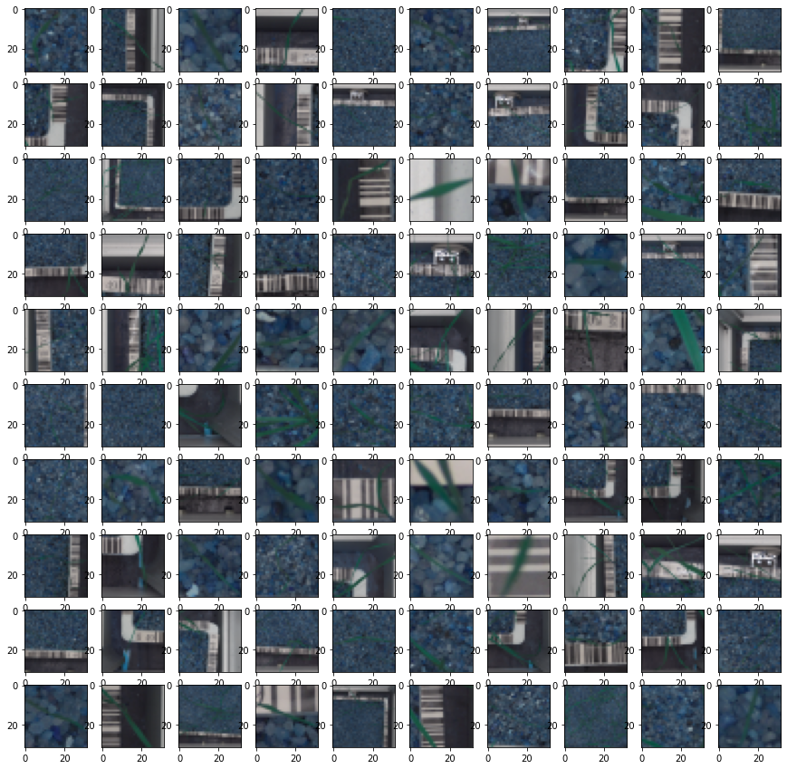

```
Label:  ['Black-grass' 'Black-grass' 'Black-grass' 'Black-grass' 'Black-grass'
 'Black-grass' 'Black-grass' 'Black-grass' 'Black-grass' 'Black-grass'
 'Black-grass' 'Black-grass' 'Black-grass' 'Black-grass' 'Black-grass'
 'Black-grass' 'Black-grass' 'Black-grass' 'Black-grass' 'Black-grass'
 'Black-grass' 'Black-grass' 'Black-grass' 'Black-grass' 'Black-grass'
 'Black-grass' 'Black-grass' 'Black-grass' 'Black-grass' 'Black-grass'
 'Black-grass' 'Black-grass' 'Black-grass' 'Black-grass' 'Black-grass'
 'Black-grass' 'Black-grass' 'Black-grass' 'Black-grass' 'Black-grass'
 'Black-grass' 'Black-grass' 'Black-grass' 'Black-grass' 'Black-grass'
 'Black-grass' 'Black-grass' 'Black-grass' 'Black-grass' 'Black-grass'
 'Black-grass' 'Black-grass' 'Black-grass' 'Black-grass' 'Black-grass'
 'Black-grass' 'Black-grass' 'Black-grass' 'Black-grass' 'Black-grass'
 'Black-grass' 'Black-grass' 'Black-grass' 'Black-grass' 'Black-grass'
 'Black-grass' 'Black-grass' 'Black-grass' 'Black-grass' 'Black-grass'
 'Black-grass' 'Black-grass' 'Black-grass' 'Black-grass' 'Black-grass'
 'Black-grass' 'Black-grass' 'Black-grass' 'Black-grass' 'Black-grass'
 'Black-grass' 'Black-grass' 'Black-grass' 'Black-grass' 'Black-grass'
 'Black-grass' 'Black-grass' 'Black-grass' 'Black-grass' 'Black-grass'
 'Black-grass' 'Black-grass' 'Black-grass' 'Black-grass' 'Black-grass'
 'Black-grass' 'Black-grass' 'Black-grass' 'Black-grass' 'Black-grass']
```

```python
fig=plt.figure(figsize=(15,15))

for i in range(1,101):
  img=X[i]
  fig.add_subplot(10,10,i)
  plt.imshow(img,cmap='gray')

plt.show()
print('Label: ', y[1:101])
```

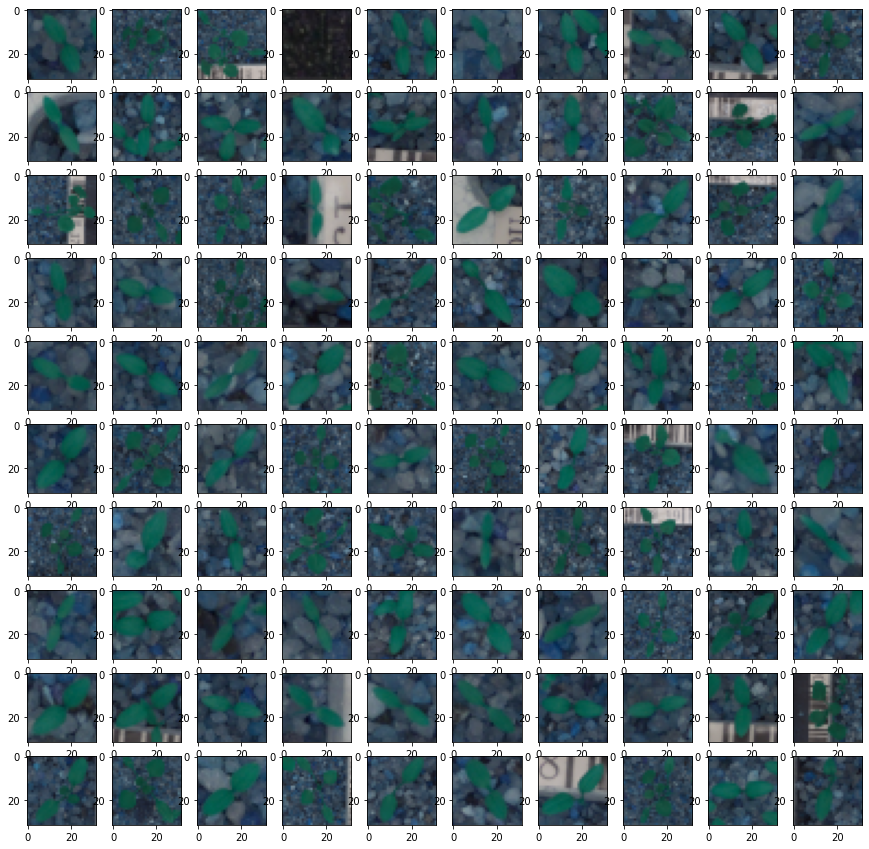

```
Label:  ['Common Chickweed' 'Common Chickweed' 'Common Chickweed'
 'Common Chickweed' 'Common Chickweed' 'Common Chickweed'
 'Common Chickweed' 'Common Chickweed' 'Common Chickweed'
 'Common Chickweed' 'Common Chickweed' 'Common Chickweed'
 'Common Chickweed' 'Common Chickweed' 'Common Chickweed'
 'Common Chickweed' 'Common Chickweed' 'Common Chickweed'
 'Common Chickweed' 'Common Chickweed' 'Common Chickweed'
 'Common Chickweed' 'Common Chickweed' 'Common Chickweed'
 'Common Chickweed' 'Common Chickweed' 'Common Chickweed'
 'Common Chickweed' 'Common Chickweed' 'Common Chickweed'
 'Common Chickweed' 'Common Chickweed' 'Common Chickweed'
 'Common Chickweed' 'Common Chickweed' 'Common Chickweed'
 'Common Chickweed' 'Common Chickweed' 'Common Chickweed'
 'Common Chickweed' 'Common Chickweed' 'Common Chickweed'
 'Common Chickweed' 'Common Chickweed' 'Common Chickweed'
 'Common Chickweed' 'Common Chickweed' 'Common Chickweed'
 'Common Chickweed' 'Common Chickweed' 'Common Chickweed'
 'Common Chickweed' 'Common Chickweed' 'Common Chickweed'
 'Common Chickweed' 'Common Chickweed' 'Common Chickweed'
 'Common Chickweed' 'Common Chickweed' 'Common Chickweed'
 'Common Chickweed' 'Common Chickweed' 'Common Chickweed'
 'Common Chickweed' 'Common Chickweed' 'Common Chickweed'
 'Common Chickweed' 'Common Chickweed' 'Common Chickweed'
 'Common Chickweed' 'Common Chickweed' 'Common Chickweed'
 'Common Chickweed' 'Common Chickweed' 'Common Chickweed'
 'Common Chickweed' 'Common Chickweed' 'Common Chickweed'
 'Common Chickweed' 'Common Chickweed' 'Common Chickweed'
 'Common Chickweed' 'Common Chickweed' 'Common Chickweed'
 'Common Chickweed' 'Common Chickweed' 'Common Chickweed'
 'Common Chickweed' 'Common Chickweed' 'Common Chickweed'
 'Common Chickweed' 'Common Chickweed' 'Common Chickweed'
 'Common Chickweed' 'Common Chickweed' 'Common Chickweed'
 'Common Chickweed' 'Common Chickweed' 'Common Chickweed'
 'Common Chickweed']
```

```python
fig=plt.figure(figsize=(15,15))

for i in range(1,101):
  img=X[1000+i]
  fig.add_subplot(10,10,i)
  plt.imshow(img)

plt.show()
print('Label: ', y[1001:1101])
```

#### Image analysis

- Images are not simple
- Contains foreground and background details with multiple objects as noise in it like rulers, stones, soil, sand, corners, alphabets
- Huge variations of data present
- Images are not focused as well
- Actual plants are covering very less pixels compared to background and noise. This will lead to high class imbalance for target object and noise.
- Simple supervised models will have hard time filtering the actual plants with soil and stones as they see the whole picture as a single input and are not splitting foreground from background.

### Creating data sets for training and testing

- Splitting Whole data set to Train, Val and Test with 80%, 10%, 10% respectively

```python
X_train, X_test, y_train, y_test = train_test_split(X, y, random_state=42, test_size=0.2)
```

```python
X_val, X_test, y_val, y_test = train_test_split(X_test, y_test, random_state=42, test_size=0.5)
```

```python
#View data set shape
print("X_train: "+str(X_train.shape))
print("X_test: "+str(X_test.shape))
print("X_val: "+str(X_val.shape))
print("y_train: "+str(y_train.shape))
print("y_test: "+str(y_test.shape))
print("y_val: "+str(y_val.shape))
```

```
X_train: (3813, 32, 32, 3)
X_test: (477, 32, 32, 3)
X_val: (477, 32, 32, 3)
y_train: (3813,)
y_test: (477,)
y_val: (477,)
```

```python
#View Raw data in train set
X_train[0]
```

```
array([[[0.18431373, 0.25882354, 0.36078432],
        [0.18039216, 0.24313726, 0.3372549 ],
        [0.13333334, 0.21176471, 0.32156864],
        ...,
        [0.17254902, 0.21960784, 0.2784314 ],
        [0.20784314, 0.25882354, 0.3137255 ],
        [0.16078432, 0.22352941, 0.28235295]],

       [[0.15294118, 0.24313726, 0.36078432],
        [0.16470589, 0.2627451 , 0.3764706 ],
        [0.11372549, 0.23529412, 0.36078432],
        ...,
        [0.18039216, 0.24313726, 0.30980393],
        [0.25490198, 0.30588236, 0.3372549 ],
        [0.18039216, 0.2509804 , 0.29411766]],

       [[0.18039216, 0.26666668, 0.36078432],
        [0.16470589, 0.25882354, 0.34901962],
        [0.15686275, 0.25882354, 0.34901962],
        ...,
        [0.16078432, 0.24705882, 0.3254902 ],
        [0.14509805, 0.2784314 , 0.28627452],
        [0.18431373, 0.25490198, 0.31764707]],

       ...,

       [[0.25490198, 0.31764707, 0.3529412 ],
        [0.2784314 , 0.36862746, 0.41568628],
        [0.23137255, 0.34901962, 0.43137255],
        ...,
        [0.1882353 , 0.23137255, 0.29803923],
        [0.19215687, 0.24313726, 0.30588236],
        [0.20392157, 0.25882354, 0.32156864]],

       [[0.21176471, 0.27058825, 0.3137255 ],
        [0.2       , 0.27450982, 0.30980393],
        [0.24313726, 0.34509805, 0.3882353 ],
        ...,
        [0.23137255, 0.28627452, 0.34901962],
        [0.1882353 , 0.24705882, 0.3137255 ],
        [0.19607843, 0.27450982, 0.3529412 ]],

       [[0.21568628, 0.2627451 , 0.32941177],
        [0.19607843, 0.26666668, 0.3372549 ],
        [0.21568628, 0.3019608 , 0.38431373],
        ...,
        [0.32156864, 0.39607844, 0.4627451 ],
        [0.18431373, 0.25882354, 0.34509805],
        [0.17254902, 0.28627452, 0.38431373]]], dtype=float32)
```

```python
#Reshaping Data sets for using in KNN model

from builtins import range
from builtins import object

num_training = X_train.shape[0]
mask = list(range(num_training))
X_train = X_train[mask]
y_train = y_train[mask]

num_test = X_test.shape[0]
mask = list(range(num_test))
X_test = X_test[mask]
y_test = y_test[mask]

num_val = X_val.shape[0]
mask = list(range(num_val))
X_val = X_val[mask]
y_val = y_val[mask]

# Reshape the image data into rows
X_train = np.reshape(X_train, (X_train.shape[0], -1))
X_test = np.reshape(X_test, (X_test.shape[0], -1))
X_val = np.reshape(X_val, (X_val.shape[0], -1))

print("X_train: "+str(X_train.shape))
print("X_test: "+str(X_test.shape))
print("X_val: "+str(X_val.shape))
print("y_train: "+str(y_train.shape))
print("y_test: "+str(y_test.shape))
print("y_val: "+str(y_val.shape))
```

```
X_train: (3813, 3072)
X_test: (477, 3072)
X_val: (477, 3072)
y_train: (3813,)
y_test: (477,)
y_val: (477,)
```

```python
print(y.view())
```

```
['Black-grass' 'Black-grass' 'Black-grass' ... 'Sugar beet' 'Sugar beet'
 'Sugar beet']
```

#### Image classification with KNN

##### KNN

- For Plant species raw data, expectations is the leaf's and other patern remain close to each other and a KNN model will be able pick up the common features and group it together
- k-nearest neighbor algorithm is for classifying objects based on closest training examples in the feature space. k-nearest neighbor algorithm is among the simplest of all machine learning algorithms. Training process for this algorithm only consists of storing feature vectors and labels of the training images. In the classification process, the unlabelled query point is simply assigned to the label of its k nearest neighbors.
- A main advantage of the KNN algorithm is that it performs well with multi-modal classes because the basis of its decision is based on a small neighborhood of similar objects. Therefore, even if the target class is multi-modal, the algorithm can still lead to good accuracy.

```python
from sklearn.metrics import accuracy_score,confusion_matrix,recall_score,f1_score,precision_score,roc_curve,log_loss,auc
from sklearn.neighbors import KNeighborsClassifier


#KNN Model with 1 neighbour

KnnModel = KNeighborsClassifier(n_neighbors=1)
KnnModel.fit(X_train,y_train)
y_predict=KnnModel.predict(X_test)
```

```python
print('Accuracy score:',accuracy_score(y_test,y_predict))
print('confuion matrix:\n',confusion_matrix(y_test,y_predict))
```

```
Accuracy score: 0.3081761006289308
confuion matrix:
 [[13  0  0  0  1  2  9  0  0  1  0  2]
 [ 2 12  1  0  3  1  2  0  7  2  4  2]
 [ 1  1 12  0  1  2  3  2  2  0  4  1]
 [17  1  0 17  2  3  6  1 16  2  1  1]
 [12  0  0  1  2  1  2  0  1  0  0  0]
 [15  1  0  2  0  6 12  0  5  0  1  1]
 [23  1  0  2  2  2 29  0  2  1  1  4]
 [ 4  1  0  3  1  0  2  5  2  1  2  2]
 [11  4  0  1  0  3 10  3 20  1  0  2]
 [ 4  2  0  1  0  0  2  2  0  5  1  1]
 [15  2  3  1  0  1  5  0  6  1 21  1]
 [20  0  0  0  4  0  4  0  2  1  0  5]]
```

- With single neighbour we are able to acheive close to 30% accuracy, but 1 neighbour is higly volatile and wont give us generalised result

```python
# Initializing the value of k and finding the accuracies on validation data
k_vals = range(1, 30, 2)
accuracies = []

for k in range(1, 30, 2):
  knn = KNeighborsClassifier(n_neighbors=k)
  knn.fit(X_train, y_train)
  score = knn.score(X_val, y_val)
  print("k value=%d, accuracy score=%.2f%%" % (k, score * 100))
  accuracies.append(score)

# finding the value of k which has the largest accuracy
i = int(np.argmax(accuracies))
print("k=%d value has highest accuracy of %.2f%% on validation data" % (k_vals[i],accuracies[i] * 100))
```

```
k value=1, accuracy score=27.67%
k value=3, accuracy score=22.85%
k value=5, accuracy score=20.75%
k value=7, accuracy score=22.43%
k value=9, accuracy score=22.64%
k value=11, accuracy score=22.43%
k value=13, accuracy score=23.27%
k value=15, accuracy score=25.16%
k value=17, accuracy score=23.90%
k value=19, accuracy score=25.16%
k value=21, accuracy score=26.00%
k value=23, accuracy score=25.37%
k value=25, accuracy score=27.46%
k value=27, accuracy score=27.46%
k value=29, accuracy score=27.04%
k=1 value has highest accuracy of 27.67% on validation data
```

- Even though we got highest accuracies at 1 neighbour but we will go ahead with k=25 for more generalized approach which showed similar high accuracies on validation data set.

```python
knn = KNeighborsClassifier(n_neighbors=25)
knn.fit(X_train, y_train)
predictions = knn.predict(X_test)
```

```python
print("EVALUATION ON TESTING DATA")
print(confusion_matrix(y_test,predictions))
print(knn.score(X_test, y_test))
```

```
EVALUATION ON TESTING DATA
[[ 3  0  0  0  1  0 23  0  1  0  0  0]
 [ 4 15  1  3  0  0  5  0  4  0  2  2]
 [ 6  4  4  0  1  0  3  0  7  0  4  0]
 [18  4  0  5  0  0 12  0 26  0  0  2]
 [ 3  0  0  0  1  0 14  0  0  0  0  1]
 [11  2  1  0  1  6 15  0  5  0  0  2]
 [16  1  0  0  3  2 36  0  5  0  1  3]
 [ 2  1  0  3  0  0  3  2  7  1  0  4]
 [10  3  0  0  0  1 11  0 28  0  0  2]
 [ 2  1  0  0  0  0  2  1  8  2  0  2]
 [20  5  1  0  0  3  9  0 10  0  7  1]
 [15  1  0  1  0  0 11  0  3  0  0  5]]
0.2389937106918239
```

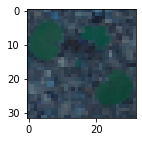

```
Prediction: ['Black-grass']
Actual: Small-flowered Cranesbill
```

```python
plt.figure(figsize=(2,2))
plt.imshow(X_test[59].reshape(32,32,3))
plt.show()
image = X_test[59]
print('Prediction:',knn.predict(image.reshape(1, -1)))
print('Actual:',y_test[59])
```

```python
plt.figure(figsize=(2,2))
plt.imshow(X_test[300].reshape(32,32,3))
plt.show()
image = X_test[300]
print('Prediction:',knn.predict(image.reshape(1, -1)))
print('Actual:',y_test[300])
```

```
Prediction: ['Scentless Mayweed']
Actual: Scentless Mayweed
```

```python
predictions = knn.predict(X_test)
print(classification_report(y_test, predictions))
```

```
                           precision    recall  f1-score   support

              Black-grass       0.03      0.11      0.04        28
                 Charlock       0.41      0.42      0.41        36
                 Cleavers       0.57      0.14      0.22        29
         Common Chickweed       0.42      0.07      0.13        67
             Common wheat       0.14      0.05      0.08        19
                  Fat Hen       0.50      0.14      0.22        43
         Loose Silky-bent       0.25      0.54      0.34        67
                    Maize       0.67      0.09      0.15        23
        Scentless Mayweed       0.27      0.51      0.35        55
          Shepherds Purse       0.67      0.11      0.19        18
Small-flowered Cranesbill       0.50      0.12      0.20        56
               Sugar beet       0.21      0.14      0.17        36

                 accuracy                           0.24       477
                macro avg       0.39      0.20      0.21       477
             weighted avg       0.37      0.24      0.23       477
```

```python
print(knn.score(X_test, y_test))
```

```
0.2389937106918239
```

- Accuracies from KNN are close to 24%.
- We can observe on each classes precision and recall are very low.
- Model is not able to identify and split relevent data from rest of the noise.
- For Plant species raw data, expectations is the leaf's and other patern remain close to each other and a KNN model will be able pick up the common features and group it together.
- While data analysis we noticed the images contains lot of noise or i few images actual plat is hardly cvering 5% of total pixels
- Executed KNN from 1 to 30 neighbours and identified best values were at 1 neighbour and 25 neighbours. We chose for 25 neighbours so that we will get a more generalized prediction on classification.
- With KNN our classification accuracies were close to 20% which are way below acceptable levels
- We can observe there is an underlying pattern to the images for both raw pixel intensities and color. KNN is not capable enough to understand the differences and classifymore accurately.

##### Issues with KNN

- KNN depends on nearest neighbours, which might not be the best choice all the time. Observed the same issue during our evaluation proces as well
- a major disadvantage of the KNN algorithm is that it uses all the features equally in computing for similarities. This can lead to classification errors, especially when there is only a small subset of features that are useful for classification.
- While data analysis we noticed the images contains lot of noise or in few images actual plant is hardly cvering 5% of total pixels

#### Image classification with Neural Network

- Using One hot encoder to convert the categories to array formats

```python
#from tensorflow.keras.utils import to_categorical
from sklearn.preprocessing import OneHotEncoder


one_hot_encoder = OneHotEncoder(sparse=False)
one_hot_encoder.fit(y_train.reshape(-1, 1))

y_train = one_hot_encoder.transform(y_train.reshape(-1, 1))
#y_train = pd.DataFrame(data=y_train, columns=one_hot_encoder.categories_)

y_test = one_hot_encoder.transform(y_test.reshape(-1, 1))
#y_test = pd.DataFrame(data=y_test, columns=one_hot_encoder.categories_)

y_val = one_hot_encoder.transform(y_val.reshape(-1, 1))
#y_val = pd.DataFrame(data=y_val, columns=one_hot_encoder.categories_)


print("Shape of y_train:", y_train.shape)

print("Shape of y_test:", y_test.shape)

print("Shape of y_val:", y_val.shape)
```

```
Shape of y_train: (3813, 12)
Shape of y_test: (477, 12)
Shape of y_val: (477, 12)
```

```python
y_train
```

```
array([[1., 0., 0., ..., 0., 0., 0.],
       [0., 0., 0., ..., 0., 0., 0.],
       [0., 0., 0., ..., 0., 0., 1.],
       ...,
       [0., 0., 0., ..., 0., 0., 0.],
       [0., 0., 0., ..., 1., 0., 0.],
       [0., 0., 1., ..., 0., 0., 0.]])
```

```python
y_test_cat = pd.DataFrame(data=y_test, columns=one_hot_encoder.categories_)
```

```python
y_test_cat
```

|  | Black-grass | Charlock | Cleavers | Common Chickweed | Common wheat | Fat Hen | Loose Silky-bent | Maize | Scentless Mayweed | Shepherds Purse | Small-flowered Cranesbill | Sugar beet |
| --- | --- | --- | --- | --- | --- | --- | --- | --- | --- | --- | --- | --- |
| 0 | 0.0 | 0.0 | 0.0 | 0.0 | 0.0 | 1.0 | 0.0 | 0.0 | 0.0 | 0.0 | 0.0 | 0.0 |
| 1 | 0.0 | 0.0 | 0.0 | 0.0 | 0.0 | 0.0 | 0.0 | 0.0 | 1.0 | 0.0 | 0.0 | 0.0 |
| 2 | 0.0 | 0.0 | 0.0 | 1.0 | 0.0 | 0.0 | 0.0 | 0.0 | 0.0 | 0.0 | 0.0 | 0.0 |
| 3 | 0.0 | 0.0 | 0.0 | 0.0 | 0.0 | 0.0 | 0.0 | 0.0 | 0.0 | 0.0 | 0.0 | 1.0 |
| 4 | 0.0 | 0.0 | 0.0 | 0.0 | 0.0 | 0.0 | 1.0 | 0.0 | 0.0 | 0.0 | 0.0 | 0.0 |
| ... | ... | ... | ... | ... | ... | ... | ... | ... | ... | ... | ... | ... |
| 472 | 0.0 | 0.0 | 0.0 | 0.0 | 0.0 | 0.0 | 0.0 | 0.0 | 0.0 | 1.0 | 0.0 | 0.0 |
| 473 | 0.0 | 0.0 | 0.0 | 0.0 | 0.0 | 0.0 | 0.0 | 0.0 | 1.0 | 0.0 | 0.0 | 0.0 |
| 474 | 0.0 | 0.0 | 0.0 | 1.0 | 0.0 | 0.0 | 0.0 | 0.0 | 0.0 | 0.0 | 0.0 | 0.0 |
| 475 | 0.0 | 0.0 | 0.0 | 1.0 | 0.0 | 0.0 | 0.0 | 0.0 | 0.0 | 0.0 | 0.0 | 0.0 |
| 476 | 0.0 | 0.0 | 0.0 | 0.0 | 0.0 | 0.0 | 1.0 | 0.0 | 0.0 | 0.0 | 0.0 | 0.0 |

477 rows × 12 columns

```python
from tensorflow.keras.models import Sequential
from tensorflow.keras.layers import Flatten, Dense, Activation
from tensorflow.keras import optimizers
from tensorflow.keras.layers import BatchNormalization, Dropout
```

```python
model = Sequential()
model.add(Flatten())
model.add(Dense(10000,kernel_initializer='he_normal'))
model.add(BatchNormalization())
model.add(Activation('relu'))
model.add(Dense(5000,kernel_initializer='he_normal'))
model.add(BatchNormalization())
model.add(Activation('relu'))
model.add(Dense(1000,kernel_initializer='he_normal'))
model.add(BatchNormalization())
model.add(Activation('relu'))
model.add(Dense(500,kernel_initializer='he_normal'))
model.add(BatchNormalization())
model.add(Activation('relu'))
model.add(Dense(250,kernel_initializer='he_normal'))
model.add(BatchNormalization())
model.add(Activation('relu'))
model.add(Dense(125,kernel_initializer='he_normal'))
model.add(BatchNormalization())
model.add(Activation('relu'))
model.add(Dense(32,kernel_initializer='he_normal'))
model.add(BatchNormalization())
model.add(Activation('relu'))
model.add(Dense(12,kernel_initializer='he_normal'))
model.add(Activation('softmax'))

#updating learning rate
adam = optimizers.Adam(lr=0.009, decay=1e-5)
# Compile the model
model.compile(loss="categorical_crossentropy", metrics=["accuracy"], optimizer="adam")

# Fit the model
model.fit(x=X_train, y=y_train, batch_size=50, epochs=10, validation_data=(X_val, y_val))
```

```
Train on 3813 samples, validate on 477 samples
```

```
<tensorflow.python.keras.callbacks.History at 0x1d4ebc0e588>
```

```python
results = model.evaluate(X_test, y_test)
print('Accuracy: %f ' % (results[1]*100))
print('Loss: %f' % results[0])
```

```
Accuracy: 32.494760
Loss: 2.577907
```

- Acheived a accuracy more than 32% on Test dataset as compared to 24% on KNN
- Will try to further finetune the model

```python
Y_pred_test_cls = (model.predict(X_test) > 0.5).astype("int32")
```

```python
plt.figure(figsize=(2,2))
plt.imshow(X_test[300].reshape(32,32,3))
plt.show()

print('Label - one hot encoded: ',y_test_cat.iloc[300] )
print('Actual Label - one hot encoded:  ', y_test[300])
print('Predicted Label - one hot encoded: ',Y_pred_test_cls[300] )
```

```
Label - one hot encoded:  Black-grass                  0.0
Charlock                     0.0
Cleavers                     0.0
Common Chickweed             0.0
Common wheat                 0.0
Fat Hen                      0.0
Loose Silky-bent             0.0
Maize                        0.0
Scentless Mayweed            1.0
Shepherds Purse              0.0
Small-flowered Cranesbill    0.0
Sugar beet                   0.0
Name: 300, dtype: float64
Actual Label - one hot encoded:   [0. 0. 0. 0. 0. 0. 0. 0. 1. 0. 0. 0.]
Predicted Label - one hot encoded:  [0 0 0 1 0 0 0 0 0 0 0 0]
```

#### NN Approach 2

```python
#Reducing complexity
```

```python
model = Sequential()
model.add(Flatten())
model.add(Dense(1000,kernel_initializer='he_normal'))
model.add(BatchNormalization())
model.add(Activation('relu'))
model.add(Dense(500,kernel_initializer='he_normal'))
model.add(BatchNormalization())
model.add(Activation('relu'))
model.add(Dense(250,kernel_initializer='he_normal'))
model.add(BatchNormalization())
model.add(Activation('relu'))
model.add(Dense(125,kernel_initializer='he_normal'))
model.add(BatchNormalization())
model.add(Activation('relu'))
model.add(Dense(32,kernel_initializer='he_normal'))
model.add(BatchNormalization())
model.add(Activation('relu'))
model.add(Dense(12,kernel_initializer='he_normal'))
model.add(Activation('softmax'))

#updating learning rate
adam = optimizers.Adam(lr=0.009, decay=1e-6)
# Compile the model
model.compile(loss="categorical_crossentropy", metrics=["accuracy"], optimizer="adam")

# Fit the model
history=model.fit(x=X_train, y=y_train, batch_size=50, epochs=25, validation_data=(X_val, y_val))
```

```
Train on 3813 samples, validate on 477 samples
```

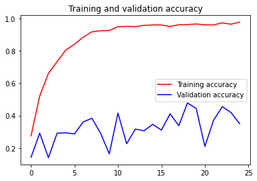

```python
acc = history.history['accuracy']
val_acc = history.history['val_accuracy']
loss = history.history['loss']
val_loss = history.history['val_loss']

epochs = range(len(acc))

plt.plot(epochs, acc, 'r', label='Training accuracy')
plt.plot(epochs, val_acc, 'b', label='Validation accuracy')
plt.title('Training and validation accuracy')
plt.legend(loc=0)
plt.figure()


plt.show()
```

- We can notice the train accuracies are increasing close to 100% but validation accuracies are around 40% only
- We will try to augment the train data and train it again so that we will get less overfitted model

```python
results = model.evaluate(X_test, y_test)
print('Accuracy: %f ' % (results[1]*100))
print('Loss: %f' % results[0])



Y_pred_test_cls = (model.predict(X_test) > 0.5).astype("int32")

plt.figure(figsize=(2,2))
plt.imshow(X_test[300].reshape(32,32,3))
plt.show()

print('Label - one hot encoded: \n',y_test_cat.iloc[300] )
print('Actual Label - one hot encoded:  ', y_test[300])
print('Predicted Label - one hot encoded: ',Y_pred_test_cls[300] )
```

```
Accuracy: 34.800839
Loss: 2.996807
```

```
Label - one hot encoded:
 Black-grass                  0.0
Charlock                     0.0
Cleavers                     0.0
Common Chickweed             0.0
Common wheat                 0.0
Fat Hen                      0.0
Loose Silky-bent             0.0
Maize                        0.0
Scentless Mayweed            1.0
Shepherds Purse              0.0
Small-flowered Cranesbill    0.0
Sugar beet                   0.0
Name: 300, dtype: float64
Actual Label - one hot encoded:   [0. 0. 0. 0. 0. 0. 0. 0. 1. 0. 0. 0.]
Predicted Label - one hot encoded:  [0 0 0 0 0 0 0 0 1 0 0 0]
```

- Test data set accuracies are around 35%

```python
import tensorflow as tf
```

```python
#Reimporting data
X_train, X_test, y_train, y_test = train_test_split(X, y, random_state=42, test_size=0.2)

X_val, X_test, y_val, y_test = train_test_split(X_test, y_test, random_state=42, test_size=0.5)
```

```python
#from tensorflow.keras.utils import to_categorical
from sklearn.preprocessing import OneHotEncoder


one_hot_encoder = OneHotEncoder(sparse=False)
one_hot_encoder.fit(y_train.reshape(-1, 1))

y_train = one_hot_encoder.transform(y_train.reshape(-1, 1))
#y_train = pd.DataFrame(data=y_train, columns=one_hot_encoder.categories_)

y_test = one_hot_encoder.transform(y_test.reshape(-1, 1))
#y_test = pd.DataFrame(data=y_test, columns=one_hot_encoder.categories_)

y_val = one_hot_encoder.transform(y_val.reshape(-1, 1))
#y_val = pd.DataFrame(data=y_val, columns=one_hot_encoder.categories_)


print("Shape of y_train:", y_train.shape)

print("Shape of y_test:", y_test.shape)

print("Shape of y_val:", y_val.shape)
```

```
Shape of y_train: (3813, 12)
Shape of y_test: (477, 12)
Shape of y_val: (477, 12)
```

```python
y_train
```

```
array([[1., 0., 0., ..., 0., 0., 0.],
       [0., 0., 0., ..., 0., 0., 0.],
       [0., 0., 0., ..., 0., 0., 1.],
       ...,
       [0., 0., 0., ..., 0., 0., 0.],
       [0., 0., 0., ..., 1., 0., 0.],
       [0., 0., 1., ..., 0., 0., 0.]])
```

```python
y_test_cat = pd.DataFrame(data=y_test, columns=one_hot_encoder.categories_)
```

- ImageDataGenerator is a preprocessing utility to generate training and testing data with common data augmentation techniques.
- Used to generate training data from Images stored in hierarchical directory structures For more options of ImageDataGenerator go to https://keras.io/preprocessing/image/
  - Rotaion Range -20
  - Width Shift Range - 0.2
  - Height Shift Range - 0.2
  - Zoom Range - 0.4 to 1.5
  - Horizontal flip - True
  - Vertical Flip - True

```python
datagen= tf.keras.preprocessing.image.ImageDataGenerator(rotation_range=20,
                                                         width_shift_range=0.2,
                                                         height_shift_range=0.2,
                                                         zoom_range=[0.4,1.5],
                                                         horizontal_flip=True,
                                                         vertical_flip=True)

datagen.fit(X_train)
```

```python
model = Sequential()
model.add(Flatten())
model.add(Dense(10000,kernel_initializer='he_normal'))
model.add(BatchNormalization())
model.add(Activation('relu'))
model.add(Dense(1000,kernel_initializer='he_normal'))
model.add(BatchNormalization())
model.add(Activation('relu'))
model.add(Dense(500,kernel_initializer='he_normal'))
model.add(BatchNormalization())
model.add(Activation('relu'))
model.add(Dense(250,kernel_initializer='he_normal'))
model.add(BatchNormalization())
model.add(Activation('relu'))
model.add(Dense(125,kernel_initializer='he_normal'))
model.add(BatchNormalization())
model.add(Activation('relu'))
model.add(Dense(32,kernel_initializer='he_normal'))
model.add(BatchNormalization())
model.add(Activation('relu'))
model.add(Dense(12,kernel_initializer='he_normal'))
model.add(Activation('softmax'))

#updating learning rate
adam = optimizers.Adam(lr=0.01, decay=1e-6)
# Compile the model
model.compile(loss="categorical_crossentropy", metrics=["accuracy"], optimizer="adam")

#Saving the best model using model checkpoint callback
model_checkpoint=tf.keras.callbacks.ModelCheckpoint('plantspecies_NN_model.h5', #where to save the model
                                                    save_best_only=True,
                                                    monitor='val_accuracy',
                                                    mode='max',
                                                    verbose=1)

history= model.fit_generator(datagen.flow(X_train, y_train, batch_size=16),
                  epochs=25,
                  validation_data=(X_val, y_val),
                  callbacks = [model_checkpoint])
history
```

```
Train for 239 steps, validate on 477 samples
Epoch 00001: val_accuracy improved from -inf to 0.16981, saving model to plantspecies_NN_model.h5
Epoch 00002: val_accuracy improved from 0.16981 to 0.18029, saving model to plantspecies_NN_model.h5
Epoch 00003: val_accuracy improved from 0.18029 to 0.29140, saving model to plantspecies_NN_model.h5
Epoch 00004: val_accuracy did not improve from 0.29140
Epoch 00005: val_accuracy did not improve from 0.29140
Epoch 00006: val_accuracy improved from 0.29140 to 0.30818, saving model to plantspecies_NN_model.h5
Epoch 00007: val_accuracy improved from 0.30818 to 0.32914, saving model to plantspecies_NN_model.h5
Epoch 00008: val_accuracy improved from 0.32914 to 0.36268, saving model to plantspecies_NN_model.h5
Epoch 00009: val_accuracy did not improve from 0.36268
Epoch 00010: val_accuracy did not improve from 0.36268
Epoch 00011: val_accuracy improved from 0.36268 to 0.38784, saving model to plantspecies_NN_model.h5
Epoch 00012: val_accuracy did not improve from 0.38784
Epoch 00013: val_accuracy did not improve from 0.38784
Epoch 00014: val_accuracy did not improve from 0.38784
Epoch 00015: val_accuracy did not improve from 0.38784
Epoch 00016: val_accuracy did not improve from 0.38784
Epoch 00017: val_accuracy did not improve from 0.38784
Epoch 00018: val_accuracy did not improve from 0.38784
Epoch 00019: val_accuracy did not improve from 0.38784
Epoch 00020: val_accuracy improved from 0.38784 to 0.40252, saving model to plantspecies_NN_model.h5
Epoch 00021: val_accuracy did not improve from 0.40252
Epoch 00022: val_accuracy improved from 0.40252 to 0.44444, saving model to plantspecies_NN_model.h5
Epoch 00023: val_accuracy did not improve from 0.44444
Epoch 00024: val_accuracy did not improve from 0.44444
Epoch 00025: val_accuracy did not improve from 0.44444
```

```
<tensorflow.python.keras.callbacks.History at 0x1d51bfaa3c8>
```

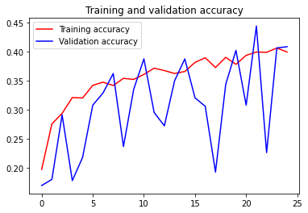

```python
acc = history.history['accuracy']
val_acc = history.history['val_accuracy']
loss = history.history['loss']
val_loss = history.history['val_loss']

epochs = range(len(acc))

plt.plot(epochs, acc, 'r', label='Training accuracy')
plt.plot(epochs, val_acc, 'b', label='Validation accuracy')
plt.title('Training and validation accuracy')
plt.legend(loc=0)
plt.figure()


plt.show()
```

- With This model we can see the train and validation accuracies are close by and hence not a overfitted model
- Still the accuracy results are less than 50%.

```python
results = model.evaluate(X_test, y_test)
print('Accuracy: %f ' % (results[1]*100))
print('Loss: %f' % results[0])
```

```
Accuracy: 37.945494
Loss: 1.701622
```

```
Accuracy: 37.945494
Loss: 1.701622
```

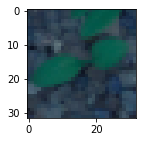

```
Label - one hot encoded:
 Black-grass                  0.0
Charlock                     0.0
Cleavers                     0.0
Common Chickweed             1.0
Common wheat                 0.0
Fat Hen                      0.0
Loose Silky-bent             0.0
Maize                        0.0
Scentless Mayweed            0.0
Shepherds Purse              0.0
Small-flowered Cranesbill    0.0
Sugar beet                   0.0
Name: 200, dtype: float64
Actual Label - one hot encoded:   [0. 0. 0. 1. 0. 0. 0. 0. 0. 0. 0. 0.]
Predicted Label - one hot encoded:  [0 0 0 1 0 0 0 0 0 0 0 0]
```

```python
results = model.evaluate(X_test, y_test)
print('Accuracy: %f ' % (results[1]*100))
print('Loss: %f' % results[0])



Y_pred_test_cls = (model.predict(X_test) > 0.5).astype("int32")

plt.figure(figsize=(2,2))
plt.imshow(X_test[200].reshape(32,32,3))
plt.show()

print('Label - one hot encoded: \n',y_test_cat.iloc[200] )
print('Actual Label - one hot encoded:  ', y_test[200])
print('Predicted Label - one hot encoded: ',Y_pred_test_cls[200] )
```

- With Neural network we were able to improve test set predictions to close to 40%.
- Even with NN we are struggling for image identification with high accuracies.
- Epochs were limited at 25 only as we will be comparing the same with CNN on similar grounds. We may acheive a bit higher accuracies with more epochs.
- NN is able to provide better result compared to KNN but it has high computation requirement and huge data to work with.

### Image Classification with CNN

```python
from tensorflow.keras.models import Sequential  # initial NN
from tensorflow.keras.layers import Dense, Dropout # construct each layer
from tensorflow.keras.layers import Conv2D # swipe across the image by 1
from tensorflow.keras.layers import MaxPooling2D # swipe across by pool size
from tensorflow.keras.layers import Flatten, GlobalAveragePooling2D
from tensorflow import keras
```

```python
X_train, X_test, y_train, y_test = train_test_split(X, y, random_state=42, test_size=0.2)

X_val, X_test, y_val, y_test = train_test_split(X_test, y_test, random_state=42, test_size=0.5)
```

```python
#from tensorflow.keras.utils import to_categorical
from sklearn.preprocessing import OneHotEncoder


one_hot_encoder = OneHotEncoder(sparse=False)
one_hot_encoder.fit(y_train.reshape(-1, 1))

y_train = one_hot_encoder.transform(y_train.reshape(-1, 1))
#y_train = pd.DataFrame(data=y_train, columns=one_hot_encoder.categories_)

y_test = one_hot_encoder.transform(y_test.reshape(-1, 1))
#y_test = pd.DataFrame(data=y_test, columns=one_hot_encoder.categories_)

y_val = one_hot_encoder.transform(y_val.reshape(-1, 1))
#y_val = pd.DataFrame(data=y_val, columns=one_hot_encoder.categories_)


print("Shape of y_train:", y_train.shape)

print("Shape of y_test:", y_test.shape)

print("Shape of y_val:", y_val.shape)
```

```
Shape of y_train: (3813, 12)
Shape of y_test: (477, 12)
Shape of y_val: (477, 12)
```

```python
y_train
```

```
array([[1., 0., 0., ..., 0., 0., 0.],
       [0., 0., 0., ..., 0., 0., 0.],
       [0., 0., 0., ..., 0., 0., 1.],
       ...,
       [0., 0., 0., ..., 0., 0., 0.],
       [0., 0., 0., ..., 1., 0., 0.],
       [0., 0., 1., ..., 0., 0., 0.]])
```

```python
y_test_cat = pd.DataFrame(data=y_test, columns=one_hot_encoder.categories_)
```

```python
y_test_cat
```

|  | Black-grass | Charlock | Cleavers | Common Chickweed | Common wheat | Fat Hen | Loose Silky-bent | Maize | Scentless Mayweed | Shepherds Purse | Small-flowered Cranesbill | Sugar beet |
| --- | --- | --- | --- | --- | --- | --- | --- | --- | --- | --- | --- | --- |
| 0 | 0.0 | 0.0 | 0.0 | 0.0 | 0.0 | 1.0 | 0.0 | 0.0 | 0.0 | 0.0 | 0.0 | 0.0 |
| 1 | 0.0 | 0.0 | 0.0 | 0.0 | 0.0 | 0.0 | 0.0 | 0.0 | 1.0 | 0.0 | 0.0 | 0.0 |
| 2 | 0.0 | 0.0 | 0.0 | 1.0 | 0.0 | 0.0 | 0.0 | 0.0 | 0.0 | 0.0 | 0.0 | 0.0 |
| 3 | 0.0 | 0.0 | 0.0 | 0.0 | 0.0 | 0.0 | 0.0 | 0.0 | 0.0 | 0.0 | 0.0 | 1.0 |
| 4 | 0.0 | 0.0 | 0.0 | 0.0 | 0.0 | 0.0 | 1.0 | 0.0 | 0.0 | 0.0 | 0.0 | 0.0 |
| ... | ... | ... | ... | ... | ... | ... | ... | ... | ... | ... | ... | ... |
| 472 | 0.0 | 0.0 | 0.0 | 0.0 | 0.0 | 0.0 | 0.0 | 0.0 | 0.0 | 1.0 | 0.0 | 0.0 |
| 473 | 0.0 | 0.0 | 0.0 | 0.0 | 0.0 | 0.0 | 0.0 | 0.0 | 1.0 | 0.0 | 0.0 | 0.0 |
| 474 | 0.0 | 0.0 | 0.0 | 1.0 | 0.0 | 0.0 | 0.0 | 0.0 | 0.0 | 0.0 | 0.0 | 0.0 |
| 475 | 0.0 | 0.0 | 0.0 | 1.0 | 0.0 | 0.0 | 0.0 | 0.0 | 0.0 | 0.0 | 0.0 | 0.0 |
| 476 | 0.0 | 0.0 | 0.0 | 0.0 | 0.0 | 0.0 | 1.0 | 0.0 | 0.0 | 0.0 | 0.0 | 0.0 |

477 rows × 12 columns

```python
model = Sequential()
model.add(Conv2D(64, (5, 5), activation='relu', input_shape=(32, 32, 3)))
model.add(MaxPooling2D((2, 2)))
model.add(Flatten())



model.add(Dense(12, activation='softmax'))

model.summary()

# compile model
model.compile(loss='categorical_crossentropy', optimizer='adam', metrics=['accuracy'])


history=model.fit(x=X_train, y=y_train, batch_size=50, epochs=25, validation_data=(X_val, y_val))
history
```

```
Model: "sequential_3"
_________________________________________________________________
Layer (type)                 Output Shape              Param #
=================================================================
conv2d (Conv2D)              (None, 28, 28, 64)        4864
_________________________________________________________________
max_pooling2d (MaxPooling2D) (None, 14, 14, 64)        0
_________________________________________________________________
flatten_3 (Flatten)          (None, 12544)             0
_________________________________________________________________
dense_20 (Dense)             (None, 12)                150540
=================================================================
Total params: 155,404
Trainable params: 155,404
Non-trainable params: 0
_________________________________________________________________
Train on 3813 samples, validate on 477 samples
```

```
<tensorflow.python.keras.callbacks.History at 0x1d4b499e048>
```

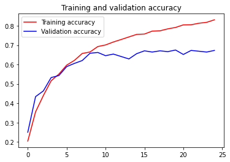

```python
acc = history.history['accuracy']
val_acc = history.history['val_accuracy']
loss = history.history['loss']
val_loss = history.history['val_loss']

epochs = range(len(acc))

plt.plot(epochs, acc, 'r', label='Training accuracy')
plt.plot(epochs, val_acc, 'b', label='Validation accuracy')
plt.title('Training and validation accuracy')
plt.legend(loc=0)
plt.figure()


plt.show()
```

- With a very basic CNN model also we can see the validation accuracies are close to 70%

```python
results = model.evaluate(X_test, y_test)
print('Accuracy: %f ' % (results[1]*100))
print('Loss: %f' % results[0])



Y_pred_test_cls = (model.predict(X_test) > 0.5).astype("int32")

plt.figure(figsize=(2,2))
plt.imshow(X_test[300].reshape(32,32,3))
plt.show()

print('Label - one hot encoded: \n',y_test_cat.iloc[300] )
print('Actual Label - one hot encoded:  ', y_test[300])
print('Predicted Label - one hot encoded: ',Y_pred_test_cls[300] )
```

```
Accuracy: 66.666669
Loss: 1.067384
```

```
Label - one hot encoded:
 Black-grass                  0.0
Charlock                     0.0
Cleavers                     0.0
Common Chickweed             0.0
Common wheat                 0.0
Fat Hen                      0.0
Loose Silky-bent             0.0
Maize                        0.0
Scentless Mayweed            1.0
Shepherds Purse              0.0
Small-flowered Cranesbill    0.0
Sugar beet                   0.0
Name: 300, dtype: float64
Actual Label - one hot encoded:   [0. 0. 0. 0. 0. 0. 0. 0. 1. 0. 0. 0.]
Predicted Label - one hot encoded:  [0 0 0 0 0 0 0 0 1 0 0 0]
```

#### Adding few additional layers in model for it to capture more features

```python
model = Sequential()
model.add(Conv2D(32, (5, 5), activation='relu', input_shape=(32, 32, 3)))
model.add(MaxPooling2D((2, 2)))
model.add(BatchNormalization())

model.add(Conv2D(filters=64, kernel_size=4, padding='same', activation='relu'))
model.add(MaxPooling2D((2, 2)))
model.add(BatchNormalization())

model.add(Conv2D(filters=128, kernel_size=3, padding='same', activation='relu'))
model.add(MaxPooling2D((2, 2)))
model.add(Dropout(0.4))

model.add(Conv2D(filters=256, kernel_size=3, padding='same', activation='relu'))
model.add(MaxPooling2D((2, 2)))
model.add(Dropout(0.4))

model.add(Flatten())
model.add(Dense(12, activation='softmax'))

model.summary()

#updating learning rate
adam = optimizers.Adam(lr=0.009, decay=1e-6)

# compile model
model.compile(loss='categorical_crossentropy', optimizer='adam', metrics=['accuracy'])

#Saving the best model using model checkpoint callback
model_checkpoint=tf.keras.callbacks.ModelCheckpoint('plantspecies_CNN_model.h5', #where to save the model
                                                    save_best_only=True,
                                                    monitor='val_accuracy',
                                                    mode='max',
                                                    verbose=1)

history=model.fit(x=X_train, y=y_train,
                  batch_size=50,
                  epochs=25,
                  validation_data=(X_val, y_val),
                  callbacks = [model_checkpoint])
history
```

```
Model: "sequential_4"
_________________________________________________________________
Layer (type)                 Output Shape              Param #
=================================================================
conv2d_1 (Conv2D)            (None, 28, 28, 32)        2432
_________________________________________________________________
max_pooling2d_1 (MaxPooling2 (None, 14, 14, 32)        0
_________________________________________________________________
batch_normalization_14 (Batc (None, 14, 14, 32)        128
_________________________________________________________________
conv2d_2 (Conv2D)            (None, 14, 14, 64)        32832
_________________________________________________________________
max_pooling2d_2 (MaxPooling2 (None, 7, 7, 64)          0
_________________________________________________________________
batch_normalization_15 (Batc (None, 7, 7, 64)          256
_________________________________________________________________
conv2d_3 (Conv2D)            (None, 7, 7, 128)         73856
_________________________________________________________________
max_pooling2d_3 (MaxPooling2 (None, 3, 3, 128)         0
_________________________________________________________________
dropout_3 (Dropout)          (None, 3, 3, 128)         0
_________________________________________________________________
conv2d_4 (Conv2D)            (None, 3, 3, 256)         295168
_________________________________________________________________
max_pooling2d_4 (MaxPooling2 (None, 1, 1, 256)         0
_________________________________________________________________
dropout_4 (Dropout)          (None, 1, 1, 256)         0
_________________________________________________________________
flatten_4 (Flatten)          (None, 256)               0
_________________________________________________________________
dense_21 (Dense)             (None, 12)                3084
=================================================================
Total params: 407,756
Trainable params: 407,564
Non-trainable params: 192
_________________________________________________________________
Train on 3813 samples, validate on 477 samples
Epoch 00001: val_accuracy improved from -inf to 0.10063, saving model to plantspecies_CNN_model.h5
Epoch 00002: val_accuracy improved from 0.10063 to 0.11740, saving model to plantspecies_CNN_model.h5
Epoch 00003: val_accuracy improved from 0.11740 to 0.12788, saving model to plantspecies_CNN_model.h5
Epoch 00004: val_accuracy improved from 0.12788 to 0.17191, saving model to plantspecies_CNN_model.h5
Epoch 00005: val_accuracy improved from 0.17191 to 0.20964, saving model to plantspecies_CNN_model.h5
Epoch 00006: val_accuracy improved from 0.20964 to 0.24948, saving model to plantspecies_CNN_model.h5
Epoch 00007: val_accuracy did not improve from 0.24948
Epoch 00008: val_accuracy improved from 0.24948 to 0.38994, saving model to plantspecies_CNN_model.h5
Epoch 00009: val_accuracy improved from 0.38994 to 0.58281, saving model to plantspecies_CNN_model.h5
Epoch 00010: val_accuracy did not improve from 0.58281
Epoch 00011: val_accuracy improved from 0.58281 to 0.62264, saving model to plantspecies_CNN_model.h5
Epoch 00012: val_accuracy improved from 0.62264 to 0.65199, saving model to plantspecies_CNN_model.h5
Epoch 00013: val_accuracy improved from 0.65199 to 0.81761, saving model to plantspecies_CNN_model.h5
Epoch 00014: val_accuracy improved from 0.81761 to 0.82600, saving model to plantspecies_CNN_model.h5
Epoch 00015: val_accuracy did not improve from 0.82600
Epoch 00016: val_accuracy did not improve from 0.82600
Epoch 00017: val_accuracy did not improve from 0.82600
Epoch 00018: val_accuracy did not improve from 0.82600
Epoch 00019: val_accuracy did not improve from 0.82600
Epoch 00020: val_accuracy did not improve from 0.82600
Epoch 00021: val_accuracy did not improve from 0.82600
Epoch 00022: val_accuracy did not improve from 0.82600
Epoch 00023: val_accuracy did not improve from 0.82600
Epoch 00024: val_accuracy did not improve from 0.82600
Epoch 00025: val_accuracy did not improve from 0.82600
```

```
<tensorflow.python.keras.callbacks.History at 0x1d4af5e75c8>
```

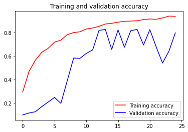

```python
acc = history.history['accuracy']
val_acc = history.history['val_accuracy']
loss = history.history['loss']
val_loss = history.history['val_loss']

epochs = range(len(acc))

plt.plot(epochs, acc, 'r', label='Training accuracy')
plt.plot(epochs, val_acc, 'b', label='Validation accuracy')
plt.title('Training and validation accuracy')
plt.legend(loc=0)
plt.figure()


plt.show()
```

- We can observe now the validation accuracies are increased closed to 80%
- still there is a noticable gap betweeen train and validation accuracies, will try to close the gap in further models

```python
results = model.evaluate(X_test, y_test)
print('Accuracy: %f ' % (results[1]*100))
print('Loss: %f' % results[0])
```

```
Accuracy: 78.616351
Loss: 0.711827
```

- Test data set accuracies are immproved closed to 80%
- Traing the model with augmented data set and 500 epochs
- ImageDataGenerator is a preprocessing utility to generate training and testing data with common data augmentation techniques.
- Used to generate training data from Images stored in hierarchical directory structures For more options of ImageDataGenerator go to https://keras.io/preprocessing/image/
  - Rotaion Range -20
  - Width Shift Range - 0.2
  - Height Shift Range - 0.2
  - Zoom Range - 0.4 to 1.5
  - Horizontal flip - True
  - Vertical Flip - True

```python
datagen= tf.keras.preprocessing.image.ImageDataGenerator(rotation_range=20,
                                                         width_shift_range=0.2,
                                                         height_shift_range=0.2,
                                                         zoom_range=[0.4,1.5],
                                                         horizontal_flip=True,
                                                         vertical_flip=True)

datagen.fit(X_train)
```

```python
model = Sequential()
model.add(Conv2D(32, (5, 5), activation='relu', input_shape=(32, 32, 3)))
model.add(MaxPooling2D((2, 2)))
model.add(BatchNormalization())

model.add(Conv2D(filters=64, kernel_size=4, padding='same', activation='relu'))
model.add(MaxPooling2D((2, 2)))
model.add(BatchNormalization())

model.add(Conv2D(filters=128, kernel_size=3, padding='same', activation='relu'))
model.add(MaxPooling2D((2, 2)))
model.add(Dropout(0.4))

model.add(Conv2D(filters=256, kernel_size=3, padding='same', activation='relu'))
model.add(MaxPooling2D((2, 2)))
model.add(Dropout(0.4))

model.add(Flatten())
model.add(Dense(12, activation='softmax'))

model.summary()

#updating learning rate
adam = optimizers.Adam(lr=0.009, decay=1e-6)

# compile model
model.compile(loss='categorical_crossentropy', optimizer='adam', metrics=['accuracy'])

#Saving the best model using model checkpoint callback
model_checkpoint=tf.keras.callbacks.ModelCheckpoint('plantspecies_CNN_model.h5', #where to save the model
                                                    save_best_only=True,
                                                    monitor='val_accuracy',
                                                    mode='max',
                                                    verbose=1)

history= model.fit_generator(datagen.flow(X_train, y_train, batch_size=32),
                  epochs=500,
                  validation_data=(X_val, y_val))
                  #callbacks = [model_checkpoint])
history
```

```
Model: "sequential_7"
_________________________________________________________________
Layer (type)                 Output Shape              Param #
=================================================================
conv2d_13 (Conv2D)           (None, 28, 28, 32)        2432
_________________________________________________________________
max_pooling2d_13 (MaxPooling (None, 14, 14, 32)        0
_________________________________________________________________
batch_normalization_20 (Batc (None, 14, 14, 32)        128
_________________________________________________________________
conv2d_14 (Conv2D)           (None, 14, 14, 64)        32832
_________________________________________________________________
max_pooling2d_14 (MaxPooling (None, 7, 7, 64)          0
_________________________________________________________________
batch_normalization_21 (Batc (None, 7, 7, 64)          256
_________________________________________________________________
conv2d_15 (Conv2D)           (None, 7, 7, 128)         73856
_________________________________________________________________
max_pooling2d_15 (MaxPooling (None, 3, 3, 128)         0
_________________________________________________________________
dropout_9 (Dropout)          (None, 3, 3, 128)         0
_________________________________________________________________
conv2d_16 (Conv2D)           (None, 3, 3, 256)         295168
_________________________________________________________________
max_pooling2d_16 (MaxPooling (None, 1, 1, 256)         0
_________________________________________________________________
dropout_10 (Dropout)         (None, 1, 1, 256)         0
_________________________________________________________________
flatten_7 (Flatten)          (None, 256)               0
_________________________________________________________________
dense_24 (Dense)             (None, 12)                3084
=================================================================
Total params: 407,756
Trainable params: 407,564
Non-trainable params: 192
_________________________________________________________________
WARNING:tensorflow:sample_weight modes were coerced from
  ...
    to
  ['...']
Train for 120 steps, validate on 477 samples
```

```
<tensorflow.python.keras.callbacks.History at 0x1d4cf5b5788>
```

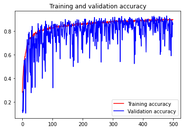

```python
acc = history.history['accuracy']
val_acc = history.history['val_accuracy']
loss = history.history['loss']
val_loss = history.history['val_loss']

epochs = range(len(acc))

plt.plot(epochs, acc, 'r', label='Training accuracy')
plt.plot(epochs, val_acc, 'b', label='Validation accuracy')
plt.title('Training and validation accuracy')
plt.legend(loc=0)
plt.figure()


plt.show()
```

- We can notice the train and test accuracies are overlaping
- This model is less overfitted and providing us with close to 90% accuracies

```python
results = model.evaluate(X_test, y_test)
print('Accuracy: %f ' % (results[1]*100))
print('Loss: %f' % results[0])
```

```
Accuracy: 89.517820
Loss: 0.309127
```

- Test data set accuracies are improved close to 90%

**Always save the model and its weights after training**

```python
model.save('./Plant_Species_Classifier_500.h5')

model.save_weights('./Plant_Species_Classifier_weights_500.h5')

#we can save using keras methods and job lib as well
```

## Let's test the model now

**Load the pre-trained saved model**

```python
from tensorflow.keras.models import load_model
import numpy as np
from tensorflow.keras.preprocessing import image

# Load the pre trained model from the HDF5 file saved previously
pretrained_model = load_model('./Plant_Species_Classifier_500.h5')
pretrained_model.load_weights('./Plant_Species_Classifier_weights_500.h5')
```

```python
model.summary()
```

```
Model: "sequential_7"
_________________________________________________________________
Layer (type)                 Output Shape              Param #
=================================================================
conv2d_13 (Conv2D)           (None, 28, 28, 32)        2432
_________________________________________________________________
max_pooling2d_13 (MaxPooling (None, 14, 14, 32)        0
_________________________________________________________________
batch_normalization_20 (Batc (None, 14, 14, 32)        128
_________________________________________________________________
conv2d_14 (Conv2D)           (None, 14, 14, 64)        32832
_________________________________________________________________
max_pooling2d_14 (MaxPooling (None, 7, 7, 64)          0
_________________________________________________________________
batch_normalization_21 (Batc (None, 7, 7, 64)          256
_________________________________________________________________
conv2d_15 (Conv2D)           (None, 7, 7, 128)         73856
_________________________________________________________________
max_pooling2d_15 (MaxPooling (None, 3, 3, 128)         0
_________________________________________________________________
dropout_9 (Dropout)          (None, 3, 3, 128)         0
_________________________________________________________________
conv2d_16 (Conv2D)           (None, 3, 3, 256)         295168
_________________________________________________________________
max_pooling2d_16 (MaxPooling (None, 1, 1, 256)         0
_________________________________________________________________
dropout_10 (Dropout)         (None, 1, 1, 256)         0
_________________________________________________________________
flatten_7 (Flatten)          (None, 256)               0
_________________________________________________________________
dense_24 (Dense)             (None, 12)                3084
=================================================================
Total params: 407,756
Trainable params: 407,564
Non-trainable params: 192
_________________________________________________________________
```

**Testing the model on a test image from one of the test folders**

```python
results = pretrained_model.evaluate(X_test, y_test)
print('Accuracy: %f ' % (results[1]*100))
print('Loss: %f' % results[0])



Y_pred_test_cls = (pretrained_model.predict(X_test) > 0.5).astype("int32")

plt.figure(figsize=(2,2))
plt.imshow(X_test[300].reshape(32,32,3))
plt.show()

print('Label - one hot encoded: \n',y_test_cat.iloc[300] )
print('Actual Label - one hot encoded:  ', y_test[300])
print('Predicted Label - one hot encoded: ',Y_pred_test_cls[300] )
```

```
Accuracy: 89.517820
Loss: 0.309127
```

```
Label - one hot encoded:
 Black-grass                  0.0
Charlock                     0.0
Cleavers                     0.0
Common Chickweed             0.0
Common wheat                 0.0
Fat Hen                      0.0
Loose Silky-bent             0.0
Maize                        0.0
Scentless Mayweed            1.0
Shepherds Purse              0.0
Small-flowered Cranesbill    0.0
Sugar beet                   0.0
Name: 300, dtype: float64
Actual Label - one hot encoded:   [0. 0. 0. 0. 0. 0. 0. 0. 1. 0. 0. 0.]
Predicted Label - one hot encoded:  [0 0 0 0 0 0 0 0 1 0 0 0]
```

- With CNN we are able to achieve close to 90% accuracies with train, validation and test data.
- We can notice the train and validation accuracies are close to each other at higher epochs.
- we will be using the same for prediction of rest of the data.

### Read the images from test folder and generate test data set

```python
#we can not directly use the image, we have to process the image.

from pathlib import Path
from skimage.io import imread
from keras.preprocessing import image
import cv2 as cv
def load_test_files(container_path):
    image_dir = Path(container_path)

    images = []
    flat_data = []
    target = []
    count = 0
    train_img = []
    fileNames = []
    for file in image_dir.iterdir():
        count += 1
        img = imread(file)
        img = cv.cvtColor(img, cv.COLOR_BGR2RGB)
        img_pred = cv.resize(img, (32, 32), interpolation=cv.INTER_AREA)
        img_pred = image.img_to_array(img_pred)
        img_pred = img_pred / 255
        train_img.append(img_pred)
        head, tail = os.path.split(file)
        fileNames.append(tail)

    X = np.array(train_img)
    y = np.array(fileNames)
    return X,y

#Using the Keras pre-processing library the image is converted to an array and then normalised.
```

```python
X_sub,FileNames_Test=load_test_files(specPathTest)
```

```python
X_sub.shape
```

```
(794, 32, 32, 3)
```

```python
FileNames_Test.shape
```

```
(794,)
```

```python
FileNames_Test[0]
```

```
'0021e90e4.png'
```

```python
Y_pred_test_cls = (pretrained_model.predict(X_sub) > 0.5).astype("int32")
```

```python
Y_pred_test_cls[0]
```

```
array([0, 0, 0, 0, 0, 0, 0, 0, 0, 0, 1, 0])
```

```python
y_test_cat = pd.DataFrame(data=Y_pred_test_cls, columns=one_hot_encoder.categories_)
```

```python
y_test_cat
```

|  | Black-grass | Charlock | Cleavers | Common Chickweed | Common wheat | Fat Hen | Loose Silky-bent | Maize | Scentless Mayweed | Shepherds Purse | Small-flowered Cranesbill | Sugar beet |
| --- | --- | --- | --- | --- | --- | --- | --- | --- | --- | --- | --- | --- |
| 0 | 0 | 0 | 0 | 0 | 0 | 0 | 0 | 0 | 0 | 0 | 1 | 0 |
| 1 | 0 | 0 | 0 | 0 | 0 | 1 | 0 | 0 | 0 | 0 | 0 | 0 |
| 2 | 0 | 0 | 0 | 0 | 0 | 0 | 0 | 0 | 0 | 0 | 0 | 1 |
| 3 | 0 | 0 | 0 | 1 | 0 | 0 | 0 | 0 | 0 | 0 | 0 | 0 |
| 4 | 0 | 0 | 0 | 0 | 0 | 0 | 0 | 0 | 0 | 0 | 0 | 1 |
| ... | ... | ... | ... | ... | ... | ... | ... | ... | ... | ... | ... | ... |
| 789 | 0 | 0 | 0 | 0 | 0 | 0 | 1 | 0 | 0 | 0 | 0 | 0 |
| 790 | 0 | 0 | 0 | 0 | 0 | 0 | 0 | 0 | 0 | 0 | 0 | 1 |
| 791 | 0 | 0 | 0 | 0 | 0 | 0 | 0 | 0 | 0 | 0 | 0 | 1 |
| 792 | 0 | 1 | 0 | 0 | 0 | 0 | 0 | 0 | 0 | 0 | 0 | 0 |
| 793 | 0 | 0 | 0 | 0 | 1 | 0 | 0 | 0 | 0 | 0 | 0 | 0 |

794 rows × 12 columns

```python
y_subm_cat=one_hot_encoder.inverse_transform(y_test_cat)
```

```python
y_subm_cat.shape
```

```
(794, 1)
```

```python
y_subm_cat=y_subm_cat.reshape(y_subm_cat.shape[0])
```

```python
res=pd.DataFrame({"file":FileNames_Test,"species":y_subm_cat})
```

```python
res.head()
```

|  | file | species |
| --- | --- | --- |
| 0 | 0021e90e4.png | Small-flowered Cranesbill |
| 1 | 003d61042.png | Fat Hen |
| 2 | 007b3da8b.png | Sugar beet |
| 3 | 0086a6340.png | Common Chickweed |
| 4 | 00c47e980.png | Sugar beet |

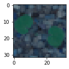

```
Small-flowered Cranesbill
```

```python
plt.figure(figsize=(2,2))
plt.imshow(X_sub[0].reshape(32,32,3))
plt.show()
print(res.species[0])
```

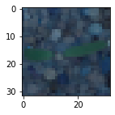

```
Fat Hen
```

```python
plt.figure(figsize=(2,2))
plt.imshow(X_sub[1].reshape(32,32,3))
plt.show()
print(res.species[1])
```

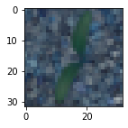

```
Sugar beet
```

```python
plt.figure(figsize=(2,2))
plt.imshow(X_sub[2].reshape(32,32,3))
plt.show()
print(res.species[2])
```

```python
res.reset_index(drop=True, inplace=True)
```

```python
res.to_csv("submission_PlantClassification.csv",index=False)
```

# Project Part 2 :

### Explain in depth why CNN out performs neural networks which in turn out perform supervised learning models when it comes to image classification.

- For this question we have to divide the models into two major groups:
  - Machine learning Algorithms
  - Deep Neural Networks (NN & CNN)
- Machine Learning Algorithms:
  - these algo's learn their mapping from provided input and output i.e. alog learns a function with diff sets of weight which help in predicting the accurate values.
  - For classification algorithms they learns from the term being used "Decision Boundries"
  - These decision boundries determine wether a new point belongs to which class or groups
  - Decision boundries could vary from linear to non-linear and these algo's are very strong to identify any relationship and map it with proper function and weight.
  - Image classification althoug a classification problem but it has much more details and relationships which ML Decision boundries are not able to map and replicate without very high computation and some times even thats not enough and becomme impossible for usinng these algos.
- Deep Neural Netowrks ( ANN & CNN ):
  - Deep Neural networks brought in a different concept called Feature Engineering
    - Feature Extraction
    - Feature Selection
  - In feature extraction, we extract all the required features for our problem statement
  - In feature selection, we select the important features that improve the performance of our deep learning model.
  - By this design change in model is giving us huge advantage over Machine learning algorithms for identifying important features of the image and relationships with outputs which helps in categorizing/predictiong classes more accurately.
- Chalanges for Neural Network:
  - NN amount of weight become unmanagable becuse it uses one perceptron for each input/pixel
  - too many parameters as its fully connected
  - each node is connected to previous and next layer making it very dense and many connections are redundant
  - Translation Invariant - NN behaves differently to shifted version of same image/zoomed/inverted. To make it learn all those you have to feed all varaions of data, which is higly difficult.
  - NN expects an identified object should appear on that specific place only which is never the real world scenario.
  - spatial information is lost when the image is flattened(matrix to vector)
  - This will make image processing difficult as the model will tend to overfit and capture unnecessary relationship
- CNN Advantages:
  - Convolution:
    - feed forward NN wont see any order in their inputs
    - CNN on other hand is better at dealing with multiple kinds of spatial deformations. It take advantage of local spatial coherence of images.
    - This means that they are able to reduce dramatically the number of operation needed to process an image by using convolution on patches of adjacent pixels, because adjacent pixels together are meaningful.
    - We also call that local connectivity.
    - convolution in neural networks is operation of finding patterns. It has kernel that with which it basically scan an image and place where kernel have 100% match is a place where pattern matched.
  - Pooling layers:
    - downscale the image
    - This is possible because we retain throughout the network, features that are organized spatially like an image, and thus downscaling them makes sense as reducing the size of the image.